# WM load and emotion: behavioral data analysis

```r
rm(list = ls())

# file path
filename = "C:/Users/Roxane Hoyer/Desktop/R/R_WM_emotion/Data/behav_data_WM_emotion_goodone.csv"
GraphSave  = "C:/Users/Roxane Hoyer/Desktop/R/R_WM_emotion/Graph/"
```

Here is the task schema with the different events and their related timing.  
The ITI depended on the time took by the participant to answer (no time limit for answering).  
N=13

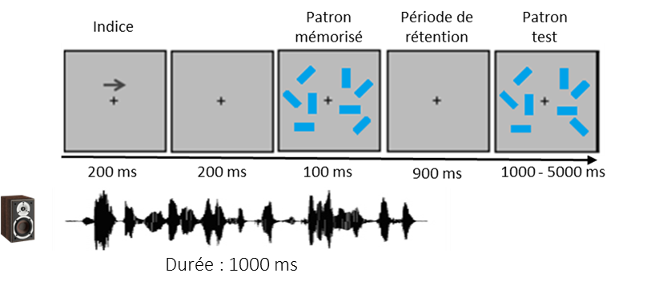

# Data visualization

## Accuracy

Number of trials by load and emotion conditions:

```
## # A tibble: 12 x 6
## # Groups:   Load, Emotion [6]
##    Load  Emotion   Response  mean.trial sd.trial sem.trial
##    <fct> <fct>     <chr>          <dbl>    <dbl>     <dbl>
##  1 Low   Neutral   Hit             54.0    22.9      4.49
##  2 Low   Neutral   Incorrect       12.4     4.52     0.903
##  3 Low   Anger     Hit             53      22.3      4.37
##  4 Low   Anger     Incorrect       13.1     5.56     1.09
##  5 Low   Happiness Hit             53.8    22.8      4.48
##  6 Low   Happiness Incorrect       12.2     5.44     1.07
##  7 High  Neutral   Hit             48.3    21.2      4.15
##  8 High  Neutral   Incorrect       17.4     7.40     1.45
##  9 High  Anger     Hit             48.6    22.0      4.32
## 10 High  Anger     Incorrect       17.5     8.25     1.62
## 11 High  Happiness Hit             48.3    21.1      4.13
## 12 High  Happiness Incorrect       17.6     8.20     1.61
```

Correct response percentage by load and emotion conditions:

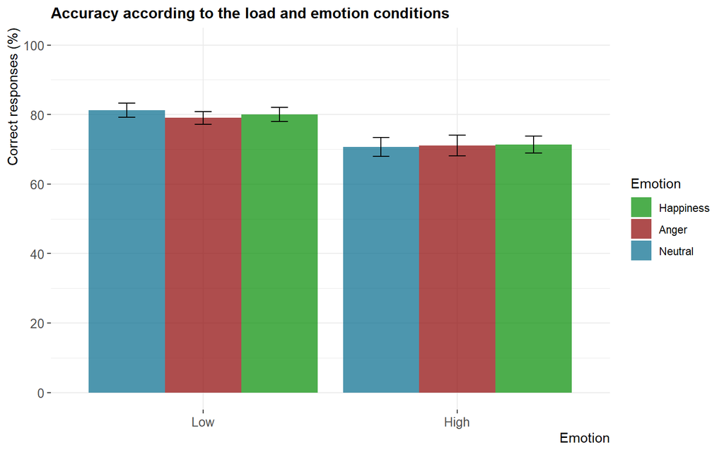

Here the error bars represent the standard error of the mean.

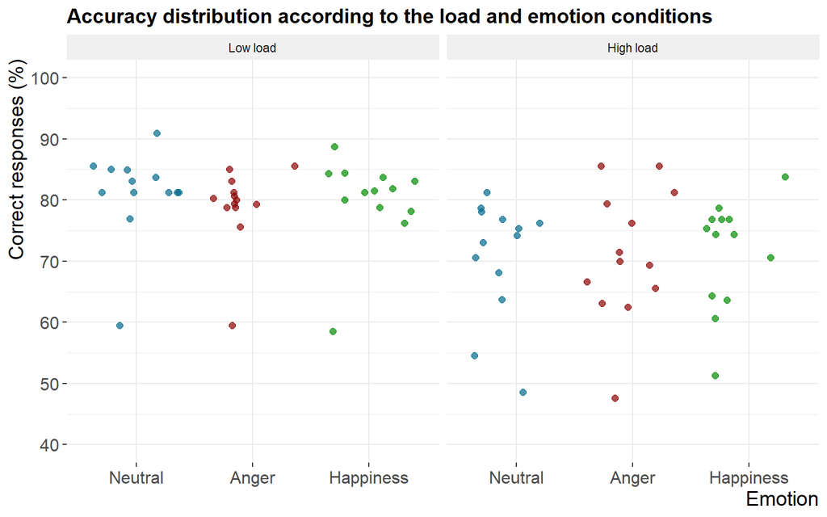

```
## # A tibble: 7 x 4
## # Groups:   Subject, Load [3]
##   Subject Load  Emotion     pct
##   <chr>   <fct> <fct>     <dbl>
## 1 PP10    High  Neutral    54.6
## 2 PP17    Low   Neutral    59.5
## 3 PP17    Low   Anger      59.5
## 4 PP17    Low   Happiness  58.5
## 5 PP17    High  Neutral    48.6
## 6 PP17    High  Anger      47.6
## 7 PP17    High  Happiness  51.4
```

One participant (PP17) seem to have struggled with the task, with a mean accuracy < 60% in all conditions. Another participant (PP10) showed an accuracy rate lower than 60% in the High Load neutral condition only.

## Reaction times

Here is a summary of the RT variable:

```
##    Min. 1st Qu.  Median    Mean 3rd Qu.    Max.
##     928    1533    1666    1759    1850    7215
```

Now let’s see how the RT distribution behave as a function or the load and emotions conditions:

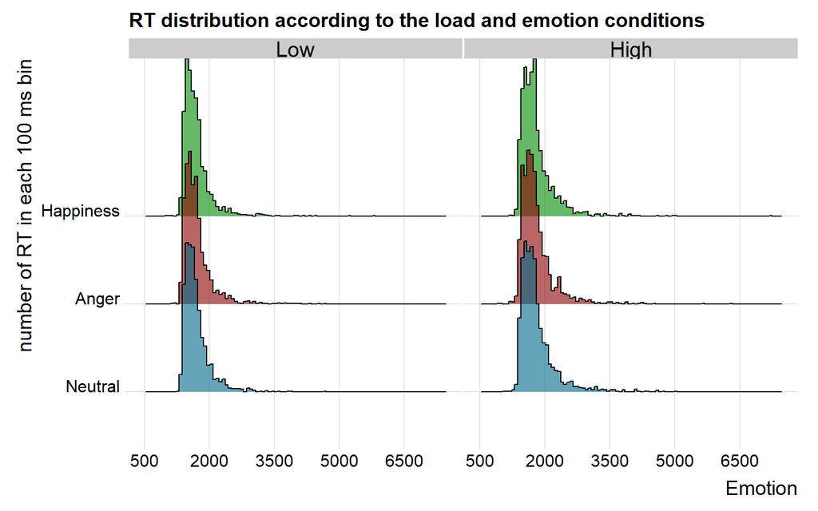

At first sight, RT distribution is likely to fit a gamma distribution.

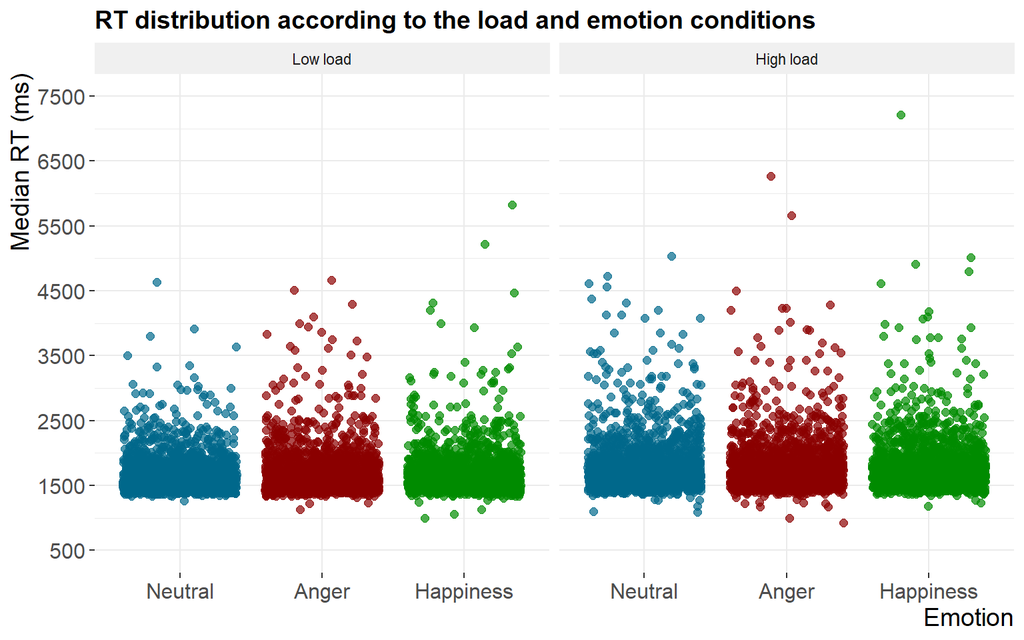

7 observations could be removed from analysis if we choose to consider them as outliers.  
These observations (data from 4 different participants) are listed below.

```
##   Condition  Response   RT MultiRep Subject Load   Emotion  Side Response_binom
## 1    LW_H_R Incorrect 5216        1     PP4  Low Happiness Right              0
## 2    HW_A_L       Hit 6266        1     PP4 High     Anger  Left              1
## 3    HW_N_R       Hit 5033        1     PP4 High   Neutral Right              1
## 4    LW_H_L       Hit 5832        1    PP12  Low Happiness  Left              1
## 5    HW_H_R       Hit 5015        1    PP13 High Happiness Right              1
## 6    HW_A_L       Hit 5666        1    PP13 High     Anger  Left              1
## 7    HW_H_L       Hit 7215        1    PP18 High Happiness  Left              1
```

The median RT distribution is quite acceptable and there is no outliers.  
This suggests that **we do not need to remove the aforementioned 7 RT > 5000 ms**.

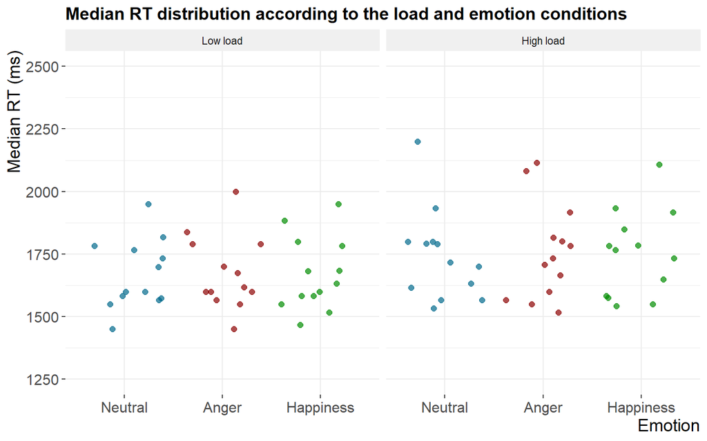

# Modelization and statistics

## Accuracy

### Modelization

Because participants had two possible type of responses (i.e., Hit and Incorrect), the errors distribution is binomial.  
Binomial Generalized Linear Mixed Models, or binomial GLMMs, are useful for modeling binary outcomes for repeated or clustered measures.  
Here, we assume that the relationship between the mean of the response and explanatory variables is linear on the logit scale.

The model is build using raw accuracy measurements (coded as “1” for Hit, and “0” for Incorrect), with 2 fixed factor (LOAD and EMOTION) and 1 random factor (SUBJECT; i.e., random intercept by subject for regression).

```
## Generalized linear mixed model fit by maximum likelihood (Laplace
##   Approximation) [glmerMod]
##  Family: binomial  ( logit )
## Formula: Response_binom ~ Emotion * Load + (1 | Subject)
##    Data: AllData
##
##      AIC      BIC   logLik deviance df.resid
##  10821.4  10872.0  -5403.7  10807.4    10279
##
## Scaled residuals:
##     Min      1Q  Median      3Q     Max
## -2.6012  0.3899  0.4839  0.5756  0.9706
##
## Random effects:
##  Groups  Name        Variance Std.Dev.
##  Subject (Intercept) 0.1216   0.3487
## Number of obs: 10286, groups:  Subject, 13
##
## Fixed effects:
##                           Estimate Std. Error z value Pr(>|z|)
## (Intercept)                1.46338    0.11696  12.512  < 2e-16 ***
## EmotionAnger              -0.11166    0.08780  -1.272    0.203
## EmotionHappiness          -0.02993    0.08889  -0.337    0.736
## LoadHigh                  -0.50117    0.08392  -5.972 2.35e-09 ***
## EmotionAnger:LoadHigh      0.11868    0.11746   1.010    0.312
## EmotionHappiness:LoadHigh  0.01849    0.11821   0.156    0.876
## ---
## Signif. codes:  0 '***' 0.001 '**' 0.01 '*' 0.05 '.' 0.1 ' ' 1
##
## Correlation of Fixed Effects:
##             (Intr) EmtnAn EmtnHp LodHgh EmA:LH
## EmotionAngr -0.389
## EmotnHppnss -0.384  0.511
## LoadHigh    -0.406  0.542  0.535
## EmtnAngr:LH  0.291 -0.747 -0.382 -0.714
## EmtnHppn:LH  0.289 -0.384 -0.752 -0.710  0.507
```

It is always complex to assess the goodness of fit for binomial models, but here is the distribution of residuals, which seems quite good for a binomial GLMM.

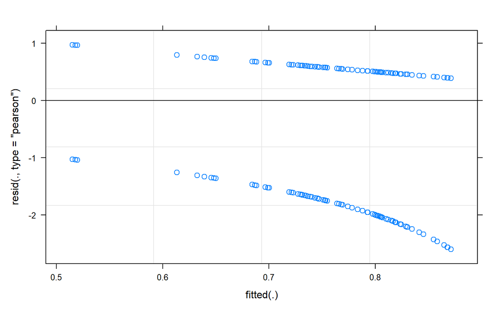

### Statistics

The type II Wald test indicate that there is a **main effect of the LOAD on accuracy**.  
There is no effect of the EMOTION factor on accuracy.

```
## Analysis of Deviance Table (Type II Wald chisquare tests)
##
## Response: Response_binom
##              Chisq Df Pr(>Chisq)
## Emotion       0.62  2       0.73
## Load         89.60  1     <2e-16 ***
## Emotion:Load  1.19  2       0.55
## ---
## Signif. codes:  0 '***' 0.001 '**' 0.01 '*' 0.05 '.' 0.1 ' ' 1
```

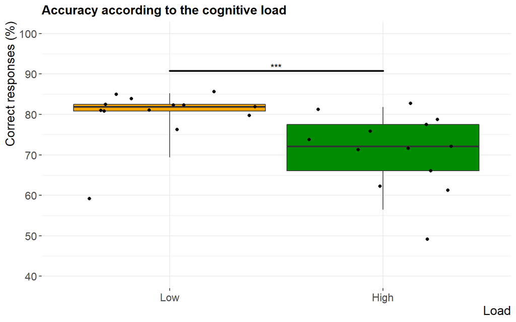

*Accuracy as a function of the load. Within each boxplot (Tukey method), the horizontal line represents the mean, the box delineates the area between the first and third quartiles (interquartile range); the vertical line represents the interval between quantile 5 and 90 (i.e., the dispersion of 90% of the population); juxtaposed to each boxplot, the dots represent individual performance.*

## RT

### Modelization

The models are build using raw RT, with 2 fixed factor (LOAD and EMOTION) and 1 random factor (SUBJECT; i.e., random intercept by subject for regression).

```
## Data: AllData
## Models:
## model.rt.01: RT ~ Load * Emotion + (1 | Subject)
## model.rt.02: RT ~ Load * Emotion + (1 | Subject)
## model.rt.03: RT ~ Load * Emotion + (1 | Subject)
## model.rt.04: RT ~ Load * Emotion + (1 | Subject)
##             npar    AIC    BIC logLik deviance  Chisq Df Pr(>Chisq)
## model.rt.01    8 148535 148593 -74260   148519
## model.rt.02    8 148663 148721 -74323   148647    0.0  0
## model.rt.03    8 144346 144404 -72165   144330 4316.7  0
## model.rt.04    8 144361 144419 -72172   144345    0.0  0
```

```
## Data: AllData
## Models:
## model.rt.01: RT ~ Load * Emotion + (1 | Subject)
## model.rt.02: RT ~ Load * Emotion + (1 | Subject)
##             npar    AIC    BIC logLik deviance Chisq Df Pr(>Chisq)
## model.rt.01    8 148535 148593 -74260   148519
## model.rt.02    8 148663 148721 -74323   148647     0  0
```

```
## Linear mixed model fit by REML ['lmerMod']
## Formula: RT ~ Load * Emotion + (1 | Subject)
##    Data: AllData
##
## REML criterion at convergence: 148477.7
##
## Scaled residuals:
##     Min      1Q  Median      3Q     Max
## -2.9798 -0.5119 -0.1866  0.2367 15.9507
##
## Random effects:
##  Groups   Name        Variance Std.Dev.
##  Subject  (Intercept)  36050   189.9
##  Residual             108540   329.5
## Number of obs: 10286, groups:  Subject, 13
##
## Fixed effects:
##                           Estimate Std. Error t value
## (Intercept)               1727.292     53.357  32.372
## LoadHigh                   114.333     11.264  10.150
## EmotionAnger                18.618     11.251   1.655
## EmotionHappiness             7.635     11.254   0.678
## LoadHigh:EmotionAnger      -25.072     15.914  -1.575
## LoadHigh:EmotionHappiness  -10.736     15.921  -0.674
##
## Correlation of Fixed Effects:
##             (Intr) LodHgh EmtnAn EmtnHp LdH:EA
## LoadHigh    -0.105
## EmotionAngr -0.106  0.500
## EmotnHppnss -0.106  0.500  0.501
## LdHgh:EmtnA  0.075 -0.708 -0.707 -0.354
## LdHgh:EmtnH  0.075 -0.707 -0.354 -0.707  0.501
```

```
## Linear mixed model fit by REML ['lmerMod']
## Formula: RT ~ Load + Emotion + (1 | Subject)
##    Data: AllData
##
## REML criterion at convergence: 148494.7
##
## Scaled residuals:
##     Min      1Q  Median      3Q     Max
## -2.9994 -0.5135 -0.1878  0.2375 15.9522
##
## Random effects:
##  Groups   Name        Variance Std.Dev.
##  Subject  (Intercept)  36053   189.9
##  Residual             108545   329.5
## Number of obs: 10286, groups:  Subject, 13
##
## Fixed effects:
##                  Estimate Std. Error t value
## (Intercept)      1733.271     53.160  32.604
## LoadHigh          102.381      6.497  15.758
## EmotionAnger        6.088      7.958   0.765
## EmotionHappiness    2.270      7.961   0.285
##
## Correlation of Fixed Effects:
##             (Intr) LodHgh EmtnAn
## LoadHigh    -0.061
## EmotionAngr -0.075  0.000
## EmotnHppnss -0.075  0.000  0.501
```

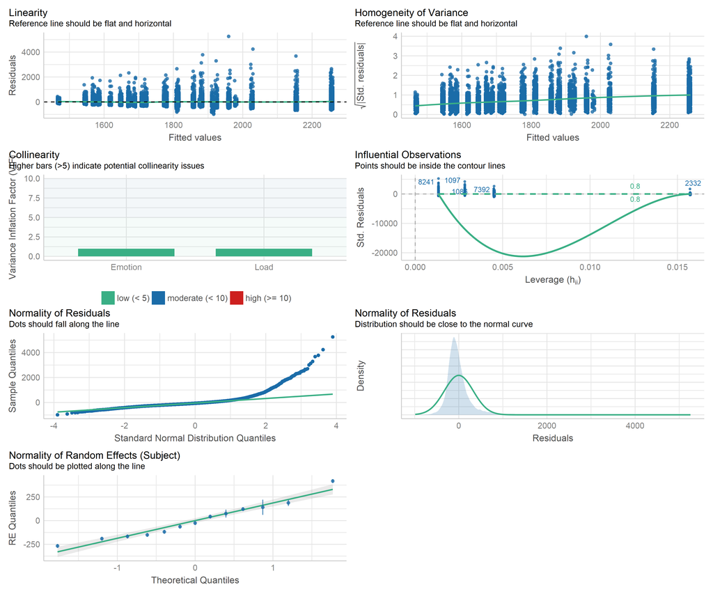

### Statistics

Here, the variance analysis revealed a **main effect of the LOAD on RT**.  
There is no effect of the EMOTION factor on RT.

```
## Analysis of Deviance Table (Type II Wald chisquare tests)
##
## Response: RT
##         Chisq Df Pr(>Chisq)
## Load    248.3  1     <2e-16 ***
## Emotion   0.6  2       0.74
## ---
## Signif. codes:  0 '***' 0.001 '**' 0.01 '*' 0.05 '.' 0.1 ' ' 1
```

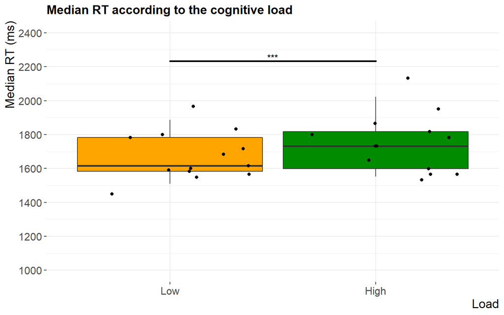

*Median RT as a function of the load. Within each boxplot (Tukey method), the horizontal line represents the mean, the box delineates the area between the first and third quartiles (interquartile range); the vertical line represents the interval between quantile 5 and 90 (i.e., the dispersion of 90% of the population); juxtaposed to each boxplot, the dots represent individual performance.*